# Homework 03

Alabboodi, Ammar (email: ANA154@pitt.edu)

today

# Overview

##### This analysis explores TikTok posts that use the hashtag **#edrecovery**, which stands for *eating disorder recovery*. The goal is to understand common themes and communities emerging around this tag by examining co-occurring hashtags, performing text-based clustering, and visualizing groupings using dimensionality reduction.

##### We obtained the data from a CSV file named `tiktok_hashtags.csv`, which contains usernames and associated hashtags used in TikTok posts. Each row represents a post and its corresponding hashtag string.

The main steps in this analysis include:

- **Parsing and normalizing hashtags**, extracting all hashtags from each post and standardizing them (lowercasing and cleaning).
- **Identifying top co-occurring hashtags** with `#edrecovery` to highlight commonly discussed topics.
- **Constructing a Document-Term Matrix (DTM)** and applying **TF–IDF (Term Frequency - Inverse Document Frequency) weighting** to emphasize significant hashtags per post.
- **Clustering posts** using **K-means** based on their hashtag profiles to uncover distinct communities or thematic groups.
- **Visualizing clusters** using **Principal Component Analysis (PCA)** to reduce dimensionality and reveal separable clusters.
- **Profiling each cluster** by identifying the most representative hashtags for interpretation.

##### This process helps us explore how TikTok users engage with the concept of recovery, the narratives they construct, and the subcultures that form within the broader #edrecovery discourse.

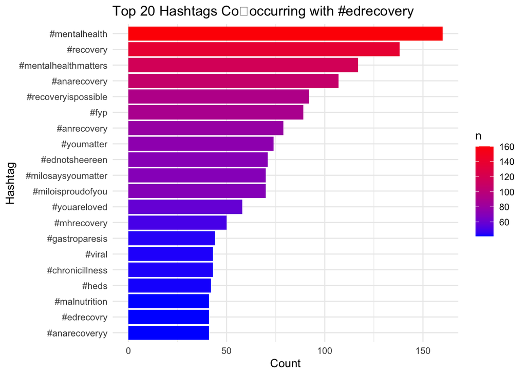

```r
# install.packages(c("tidyverse","tidytext","tm","ggplot2","factoextra"))
library(tidyverse)
library(tidytext)
library(tm)
library(ggplot2)
library(factoextra)
# Load & parse
df <- read_csv("tiktok_hashtags.csv")
df <- df %>%
  mutate(
    # extract all "#word" tokens
    tags = str_extract_all(hashtags, "#\\w+"),
    # normalize: lowercase + replace zero→o + unique
    tags = map(tags, ~ unique(tolower(gsub("0", "o", .x)))),
    # add a doc_id for later joins
    doc_id = row_number()
  )

# Co‑occurrence with #edrecovery
ed_df <- df %>%
  filter(map_lgl(tags, ~ "#edrecovery" %in% .x))

co_occur <- ed_df %>%
  unnest(tags) %>%
  filter(tags != "#edrecovery") %>%
  count(tags, sort = TRUE) %>%
  slice_head(n = 20)

ggplot(co_occur, aes(x = reorder(tags, n), y = n, fill = n)) +
  geom_col() +
  coord_flip() +
  scale_fill_gradient(low = "blue", high = "red") +
  labs(
    title = "Top 20 Hashtags Co‑occurring with #edrecovery",
    x = "Hashtag", y = "Count"
  ) +
  theme_minimal()
```

## Co‑occurrence Analysis

To better understand the thematic context of posts using **#edrecovery**, we first identified all hashtags that co-occur with it. After loading and parsing the dataset, we extracted hashtags from each post, normalized them by lowercasing and replacing zeros with the letter “o”, and assigned a unique document ID to each entry.

We then filtered the dataset to include only those posts containing `#edrecovery` and computed the frequency of all other hashtags that appear alongside it. The top 20 co-occurring hashtags were visualized using a horizontal bar chart with a gradient fill, emphasizing which tags most frequently accompany `#edrecovery`.

This analysis gives us an initial glimpse into the most common themes and conversations that surround the recovery community on TikTok.

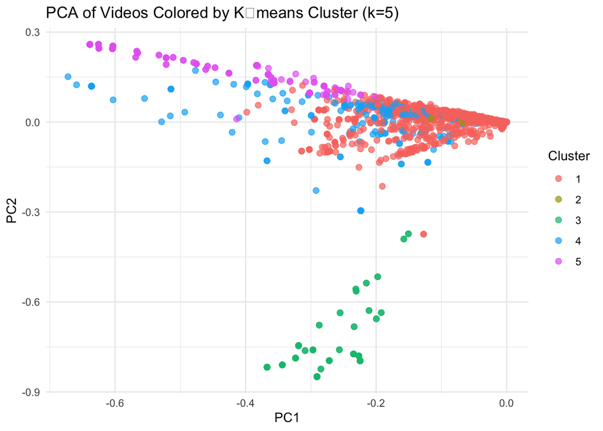

```r
# Build a DTM with TF‑IDF for all videos
docs <- df %>%
  transmute(
    doc_id,
    text = map_chr(tags, paste, collapse = " ")
  )

dtm <- docs %>%
  unnest_tokens(term, text) %>%
  count(doc_id, term, sort = FALSE) %>%
  cast_dtm(doc_id, term, n)

# apply TF‑IDF
dtm_tfidf <- weightTfIdf(dtm)
m <- as.matrix(dtm_tfidf)


# Remove empty documents
non_empty <- rowSums(m) > 0
m_nz      <- m[non_empty, ]

# L2‑normalize each row
row_norms <- sqrt(rowSums(m_nz^2))
m_nz      <- m_nz / row_norms

# Choose k ≤ nrow(m_nz)−1
k <- min(5, nrow(m_nz) - 1)
set.seed(42)
km <- kmeans(m_nz, centers = k, nstart = 25)

# PCA on the already‐normalized matrix
pca_res <- prcomp(m_nz, center = FALSE, scale. = FALSE)
scores  <- data.frame(
  PC1     = pca_res$x[,1],
  PC2     = pca_res$x[,2],
  cluster = factor(km$cluster)
)

# Plot
library(ggplot2)
ggplot(scores, aes(x = PC1, y = PC2, color = cluster)) +
  geom_point(alpha = 0.7, size = 2) +
  labs(
    title = paste0("PCA of Videos Colored by K‑means Cluster (k=", k, ")"),
    x = "PC1", y = "PC2", color = "Cluster"
  ) +
  theme_minimal()
```

## Clustering and Dimensionality Reduction

To identify latent themes among all TikTok posts—not just those containing `#edrecovery`—we constructed a **Document-Term Matrix (DTM)** using the full set of normalized hashtags. We applied **TF–IDF weighting** to emphasize hashtags that are more informative within individual posts while down-weighting those that are too common across the dataset.

After removing empty documents, we performed **L2 normalization** on the TF–IDF matrix to prepare it for clustering. We used **K-means clustering** (with `k` set dynamically to a maximum of 5, or fewer if the dataset was smaller) to group posts based on hashtag similarity.

### Graph Reading

That scatter is a map of videos in a two‑dimensional “hashtag space,” where:

**PC1 (x‑axis)** captures the single biggest direction of variation in how videos use hashtags.

**PC2 (y‑axis)** captures the next‑biggest, orthogonal direction of variation.

**Clusters (colors):** Videos in the same color are those that the k‑means algorithm judged to have similar TF–IDF hashtag signatures.

**Distance from each other:** Two videos plotted close together used almost the same mix of hashtags.

**Distance from the origin:** Videos far out on PC1 or PC2 have “extreme” hashtag mixes in that direction. Videos near (0,0) use a more “average” combination. **Cluster separation:** Well‑separated blobs mean distinct hashtag communities. Overlap suggests videos that mix hashtags from multiple themes.

```r
loadings <- as.data.frame(pca_res$rotation[,1:2])
# show top positive/negative hashtags on PC1
head(arrange(loadings, desc(PC1)), 10)
```

```
##                      PC1 PC2
## canonevent             0   0
## innerchild             0   0
## positivemindset        0   0
## grateful               0   0
## charlesleclerc         0   0
## livelovelaugh          0   0
## controversialopinion   0   0
## outsideclothes         0   0
## calendar               0   0
## months                 0   0
```

```r
head(arrange(loadings, PC1), 10)
```

```
##                           PC1         PC2
## edsheeranrecoveryy -0.2949208  0.13256057
## mentalhealth       -0.2909503 -0.03538639
## neda               -0.2742561  0.13197440
## anarecovery        -0.2724240  0.10145193
## foodfreedom        -0.2550684  0.11973645
## edrecovery         -0.2235223 -0.29566749
## fearfood           -0.2171127  0.11493648
## recovery           -0.2004076  0.05097418
## fyp                -0.1974554  0.05704970
## ed                 -0.1920510  0.07676979
```

```r
library(dplyr)
library(tidyr)

# --- after you build `docs` and `dtm_tfidf` and do:
m <- as.matrix(dtm_tfidf)

# 1. Get the doc_ids that appear as rows in m
valid_doc_ids <- as.integer(rownames(m))

# 2. (Optional) further drop any all-zero rows, if you did L2-normalize
non_zero_mask   <- rowSums(m) > 0
valid_doc_ids   <- valid_doc_ids[non_zero_mask]
m_nz            <- m[non_zero_mask, , drop = FALSE]

# 3. Run k-means on the filtered matrix
k <- min(5, nrow(m_nz) - 1)
set.seed(42)
km <- kmeans(m_nz, centers = k, nstart = 25)
```

```r
# 4. Build a map of doc_id → cluster
cluster_map <- tibble(
  doc_id  = valid_doc_ids,
  cluster = factor(km$cluster)
)

# 5. Subset your original df by those doc_ids and join
df_nz <- df %>%
  filter(doc_id %in% valid_doc_ids) %>%
  left_join(cluster_map, by = "doc_id")

# 6. Now unnest and tally top tags per cluster
top_tags_per_cluster <- df_nz %>%
  unnest(tags) %>%
  group_by(cluster, tags) %>%
  summarise(count = n(), .groups = "drop") %>%
  arrange(cluster, desc(count)) %>%
  group_by(cluster) %>%
  slice_head(n = 5)

print(top_tags_per_cluster)
```

```
## # A tibble: 18 × 3
## # Groups:   cluster [5]
##    cluster tags          count
##    <fct>   <chr>         <int>
##  1 1       #vent            13
##  2 1       #fyp              7
##  3 1       #ed               2
##  4 1       #21               1
##  5 1       #airportcrush     1
##  6 2       #real            28
##  7 3       #london           6
##  8 3       #clairo           1
##  9 3       #fionaapple       1
## 10 3       #kingsroad        1
## 11 3       #model            1
## 12 4       #fyp            751
## 13 4       #recovery       465
## 14 4       #mentalhealth   457
## 15 4       #edrecovery     380
## 16 4       #ed             305
## 17 5       #onthisday        3
## 18 5       #collegelife      2
```

# Cluster Interpretation of #edrecovery TikTok Hashtag Data

## Cluster 1: **#vent — Emotional Expression & Personal Struggles**

**Top hashtags:**  
`#vent`, `#fyp`, `#ed`, `#21`, `#airportcrush`

**Description:**  
This cluster likely represents users sharing **personal stories**, emotional vulnerability, and possibly early-stage recovery narratives. Tags like `#vent` and `#ed` hint at **open emotional release**, while `#airportcrush` and `#21` add a sense of youth and personal anecdotes.

## Cluster 2: **#real — Authenticity and Anti-Perfection**

**Top hashtags:**  
`#real`

**Description:**  
A minimal cluster dominated by `#real`. Suggests content focused on **authenticity**, **anti-glamour**, and **unfiltered mental health journeys**. Likely creators rejecting the curated nature of TikTok in favor of “what it’s really like.”

## Cluster 3: **#london — Aesthetic & Cultural Identity**

**Top hashtags:**  
`#london`, `#clairo`, `#fionaapple`, `#kingsroad`, `#model`

**Description:**  
This cluster reflects a niche aesthetic — **urban, alternative, or indie-inspired recovery content**. The inclusion of artists like `#clairo` and `#fionaapple` plus location tags points to **cultural and aesthetic framing** of mental health and identity.

## Cluster 4: **#fyp — Mainstream Recovery & Mental Health**

**Top hashtags:**  
`#fyp`, `#recovery`, `#mentalhealth`, `#edrecovery`, `#ed`

**Description:**  
The largest and most central cluster. Contains **general, highly visible** recovery content aimed at wide audiences. Likely to show up on TikTok’s **For You Page**. Themes include awareness, solidarity, and mainstream mental health narratives.

## Cluster 5: **#collegelife — Student & Nostalgia Niche**

**Top hashtags:**  
`#onthisday`, `#collegelife`

**Description:**  
Small cluster possibly focused on **academic life** and **personal reflection**. May include recovery stories related to school stress or identity during college years, or throwback-style memory sharing.